# Map Example

Michael Samuel

January 22, 2019

- Michael Samuel
- samfam921@gamil.com
- Michael.Samuel@cdoph.ca.gov
- https://mcsamueldatasci.github.io/Data_Science_Team/
- https://github.com/mcSamuelDataSci/Data_Science_Team

The library() function loads “packages” that perfrom special functions into the workspace.

- the dplyr packages is a workhorse for data manipulation
- the tigris package connect to the US census and reads in geographic “shape” files. It requires a free “census key” to run
- tmap is the R package I use for mapping. There are many others.

```r
library(dplyr)
library(tigris)
library(tmap)
options(tigris_class = "sf")  # Read shape files as Simiple Features objects
```

This step reads in a dataset from the cloud on votting patterns in Califonira. The dataset is from a California Open Data Set. The main portal home pages is here https://data.chhs.ca.gov/

```r
voterData.t <- read.csv("https://data.chhs.ca.gov/dataset/40fd0792-2bfd-4303-a848-fc5cb4338295/resource/c384c86a-49d2-4128-8389-b2701ff0bc35/download/voter-registration-2002-2010.csv",as.is=TRUE)
```

This little step reads in a census-tract level geographic “shape file” for California from the US census. (A free “key” from the US Census in needed if you want to run it yourself; available here https://api.census.gov/data/key_signup.html. )

```r
tracts_CA   <- tracts(state = "CA", cb = TRUE)
```

```r
voterData <- filter(voterData.t, geotype=="CT",
                                 reportyear==2010,
                                 race_eth_name=="Total",
                                 type == "voted/registered") %>%
             transform(GEOID=paste0("0",geotypevalue))
```

This step merges the data using “join”

```r
map.1    <- left_join(tracts_CA, voterData, by="GEOID")
```

This step makes a very simple map, with coloring based on the percent in the census tract who voted

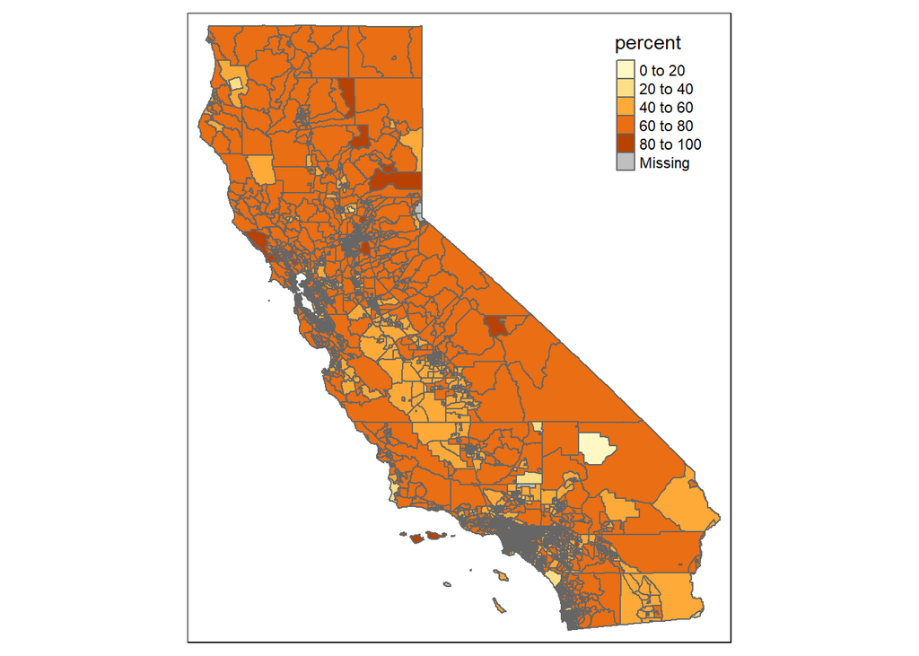

```r
#tmap_mode("view")
tm_shape(map.1) + tm_polygons(col="percent")
```

This step filters the data to just Conta Costa County, and re-maps

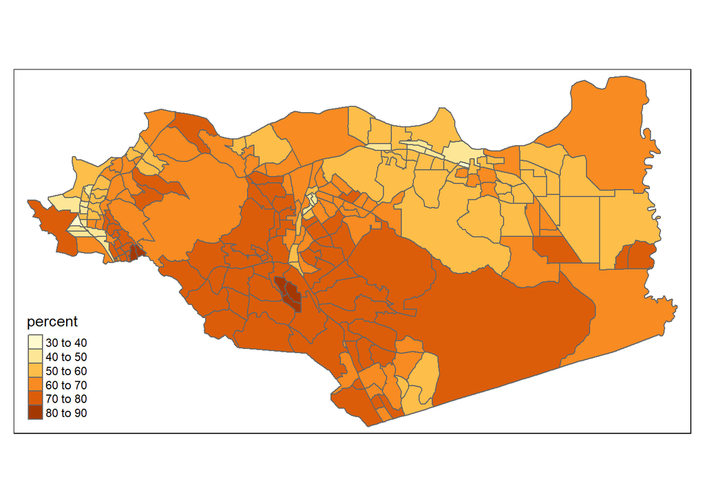

```r
map.2 <- filter(map.1,county_name == "Contra Costa")

tm_shape(map.2) + tm_polygons(col="percent")
```